[figure not shown]

# Assignment 4

In this assignment, you'll combine the assignment 3 data set with nutrition data from the [USDA Food Composition Databases](https://ndb.nal.usda.gov/ndb/search/list). The CSV file `fresh.csv` contains the fresh fruits and vegetables data you extracted in assignment 3.

The USDA Food Composition Databases have a [documented](https://ndb.nal.usda.gov/ndb/doc/index) web API that returns data in JSON format . You need a key in order to use the API. Only 1000 requests are allowed per hour, so it would be a good idea to use [caching](https://pypi.python.org/pypi/requests-cache).

[Sign up for an API key here](https://api.data.gov/signup/). The key will work with any Data.gov API. You may need the key again later in the quarter, so make sure you save it.

These modules may be useful:

- [requests](http://docs.python-requests.org/en/master/user/quickstart/)
- [requests_cache](https://pypi.python.org/pypi/requests-cache)
- [urlparse](https://docs.python.org/2/library/urlparse.html)
- [pandas](http://pandas.pydata.org/pandas-docs/stable/)

The following three cells are: (1) the libraries I used, (2) a call to cache information pulled from the USDA Food Composition Database, and (3) my personal API key. </font>

```python
# LIBRARIES
import requests
import pandas as pd
import numpy as np
import re
import requests_cache
import seaborn as sns
import matplotlib.pyplot as plt
```

```python
# CACHE DATA
requests_cache.install_cache("demo_cache")
```

```python
# API Key
key = "xnmY3s4Sb03ylPESSRNnjoHepFWUd4Tr498PeScP"
```

# Exercise 1.1

Read the [search request documentation](https://ndb.nal.usda.gov/ndb/doc/apilist/API-SEARCH.md), then write a function called `ndb_search()` that makes a search request. The function should accept the search term as an argument. The function should return the search result items as a list (for 0 items, return an empty list).

Note that the search url is: `https://api.nal.usda.gov/ndb/search`

As an example, a search for `"quail eggs"` should return this list:

```
[{u'ds': u'BL',
  u'group': u'Branded Food Products Database',
  u'name': u'CHAOKOH, QUAIL EGG IN BRINE, UPC: 044738074186',
  u'ndbno': u'45094707',
  u'offset': 0},
 {u'ds': u'BL',
  u'group': u'Branded Food Products Database',
  u'name': u'L&W, QUAIL EGGS, UPC: 024072000256',
  u'ndbno': u'45094890',
  u'offset': 1},
 {u'ds': u'BL',
  u'group': u'Branded Food Products Database',
  u'name': u'BUDDHA, QUAIL EGGS IN BRINE, UPC: 761934535098',
  u'ndbno': u'45099560',
  u'offset': 2},
 {u'ds': u'BL',
  u'group': u'Branded Food Products Database',
  u'name': u'GRAN SABANA, QUAIL EGGS, UPC: 819140010103',
  u'ndbno': u'45169279',
  u'offset': 3},
 {u'ds': u'BL',
  u'group': u'Branded Food Products Database',
  u'name': u"D'ARTAGNAN, QUAIL EGGS, UPC: 736622102630",
  u'ndbno': u'45178254',
  u'offset': 4},
 {u'ds': u'SR',
  u'group': u'Dairy and Egg Products',
  u'name': u'Egg, quail, whole, fresh, raw',
  u'ndbno': u'01140',
  u'offset': 5}]
```

As usual, make sure you document and test your function.

The following function pulls up the search results from the USDA Food Composition Database, i.e. a document of foods related to a food you searched for. </font>

```python
# SIMPLE DATA BASE FUNCTION
def ndb_search(this_term, key):
    """
    Input: A search term (string) and a API key (string)
    Output: A list of query results
    Performs a standard search query with no particular food group specified
    """
    base_url = "https://api.nal.usda.gov/ndb/search/"
    key_term = "&api_key=" + key
    final_url = base_url + "?format=json&q=" + this_term + key_term
    #print(final_url)
    request = requests.get(final_url)
    request_json = request.json()
    try:
        return request_json["list"]["item"]
    except:
        #return 0
        return([np.NaN])

# TEST TRY ON WATERMELON
# ndb_search("watermelon, raw", key)
```

# Exercise 1.2

Use your search function to get NDB numbers for the foods in the `fresh.csv` file. It's okay if you don't get an NDB number for every food, but try to come up with a strategy that gets most of them. Discuss your strategy in a short paragraph.

Hints:

- The foods are all raw and unbranded.
- You can test search terms with the [online search page](https://ndb.nal.usda.gov/ndb/search/list).
- You can convert the output of `ndb_search()` to a data frame with `pd.DataFrame()`.
- The string methods for [Python](https://docs.python.org/2/library/stdtypes.html#string-methods) and [Pandas](http://pandas.pydata.org/pandas-docs/stable/text.html#method-summary) are useful here. It's okay if you use *simple* regular expressions in the Pandas methods, although this exercise can be solved without them.
- You can merge data frames that have a column in common with `pd.merge()`.

```python
# READING IN DATA
fresh = pd.read_csv("fresh.csv")
```

The following function is an altered version of the function I created for Exercise 1.1. Instead of taking in a search term and the API key as parameters, ndb_search2 takes in a row number (from 0 on), a dataframe, and the API key. Depending on whether the food item we are searching for on the database is a fruit or a vegetable, this function creates a search specific to fruit or vegetable.  
I was able to use this function in a list comprehension to return the same sort of results lists as in Exercise 1.1. </font>

```python
# REVISED NDB_SEARCH FUNCTION
def ndb_search2(row, df, key):
    """
    Input: A row index (Pandas dataframe index), a dataframe (Pandas dataframe), and an API key (string)
    Output: A list of query results
    Performs a specialized search for foods in fresh
    """
    # PARSE DATAFRAME FOR INFORMATION
    this_row = df.iloc[row]
    this_term = (this_row[5]).replace("_", " ") # name
    fg = this_row[6] # fruit or vegetable

    # CONSTRUCT QUERY CALL
    base_url = "https://api.nal.usda.gov/ndb/search/"
    key_term = "&api_key=" + key
    if fg == "fruit":
        final_url = base_url + "?format=json&q=" + this_term + "&ds=Standard Reference" +"&fg=Fruits and Fruit Juices" + key_term
    else:
        final_url = base_url + "?format=json&q=" + this_term + "&ds=Standard Reference" + "&fg=Vegetables and Vegetable Products" + key_term
    request = requests.get(final_url)
    request_json = request.json()

    # CATCH FOR ERRORS
    try:
        return request_json["list"]["item"]
    except:
        return([np.NaN])
```

```python
results_list = [ndb_search2(x, fresh, key) for x in range(len(fresh))]
#results_list
```

To extract information from the results procured from using ndb_search2, I created the following function that uses regex to find the NDB numbers. I used a list comprehension in order to save the numbers to a list, then converted the list to a Pandas Series in order to hardcode the final NDB numbers (for completion of Exercise 1.4). </font>

```python
def ndb_no(entry):
    try:
        no = re.search("\d{5}", str(entry))
        no = no.group(0)
        return no
    except:
        return np.NaN
```

```python
numbers_list = [ndb_no(x) for x in results_list]
numbers_list = pd.Series(numbers_list)
```

```python
# HARDCODED FOR 1.4
numbers_list[12] = "09148" #KIWI
numbers_list[32] = "09038" # AVOCADOS
numbers_list[42] = "11161" # COLLARD GREENS

#numbers_list
```

Lastly, I added a new column to the fresh Data Frame for the NDB numbers called "ndb_no". </font>

```python
# Append to existing dataframe "fresh"
fresh["ndb_no"] = numbers_list
fresh.head()
```

|  | form | price_per_lb | yield | lb_per_cup | price_per_cup | food | type | ndb_no |
| --- | --- | --- | --- | --- | --- | --- | --- | --- |
| 0 | Fresh1 | 0.333412 | 0.52 | 0.330693 | 0.212033 | watermelon | fruit | 09326 |
| 1 | Fresh1 | 0.535874 | 0.51 | 0.374786 | 0.393800 | cantaloupe | fruit | 09181 |
| 2 | Fresh1 | 1.377962 | 0.74 | 0.407855 | 0.759471 | tangerines | fruit | 09218 |
| 3 | Fresh1 | 2.358808 | 0.94 | 0.319670 | 0.802171 | strawberries | fruit | 09316 |
| 4 | Fresh1 | 1.827416 | 0.94 | 0.363763 | 0.707176 | plums | fruit | 09279 |

# Exercise 1.3

Read the [food reports V2 documentation](https://ndb.nal.usda.gov/ndb/doc/apilist/API-FOOD-REPORTV2.md), then write a function called `ndb_report()` that requests a *basic* food report. The function should accept the NDB number as an argument and return the list of nutrients for the food.

Note that the report url is: `https://api.nal.usda.gov/ndb/V2/reports`

For example, for `"09279"` (raw plums) the first element of the returned list should be:

```
{u'group': u'Proximates',
 u'measures': [{u'eqv': 165.0,
   u'eunit': u'g',
   u'label': u'cup, sliced',
   u'qty': 1.0,
   u'value': u'143.93'},
  {u'eqv': 66.0,
   u'eunit': u'g',
   u'label': u'fruit (2-1/8" dia)',
   u'qty': 1.0,
   u'value': u'57.57'},
  {u'eqv': 151.0,
   u'eunit': u'g',
   u'label': u'NLEA serving',
   u'qty': 1.0,
   u'value': u'131.72'}],
 u'name': u'Water',
 u'nutrient_id': u'255',
 u'unit': u'g',
 u'value': u'87.23'}
```

Be sure to document and test your function.

Similar to the function in Exercise 1.1, this function returns results from the USDA Food Composition Database. However, these reports give information about nutrition. </font>

```python
def ndb_report(ndb_no, key):
    """
    Input: NDB number (string) and API Key (String)
    Output: Nutrition report  from USDA food composition database (List of dictionaries)
    Returns basic nutrition report of desired food item
    """
    final_url = "https://api.nal.usda.gov/ndb/V2/reports?ndbno="+str(ndb_no)+"&type=b&format=json&api_key="+key
    request = requests.get(final_url)
    request_json = request.json()
    return(request_json["foods"][0]["food"]["nutrients"])

# Testing ndb_report function with the raw plums' ndb number
# ndb_report("09279", key)
```

# Exercise 1.4

Which foods provide the best combination of price, yield, and nutrition? You can use kilocalories as a measure of "nutrition" here, but more a detailed analysis is better. Use plots to support your analysis.

This exercise called for several parts. I am breaking this exercise into these parts: (1) Compiling Information into the fresh Data Frame, (2) Visualization, and (3) Creating an Additive Model. </font>

## Compiling Information Into fresh DataFrame

```python
# GET ALL INFORMATION
# INITIALIZE
kilocalories, water, protein, sugar, iron, vitamin_c = [], [], [], [], [], []

# FOR LOOP TO RETRIEVE INFO FROM THE REPORTS
for number in fresh["ndb_no"]:
    # CHECK FOR NULL VALUES
    if pd.isnull(number):
        kilocalories.append(np.NaN)
        water.append(np.NaN)
        protein.append(np.NaN)
        iron.append(np.NaN)
        vitamin_c.append(np.NaN)
        sugar.append(np.NaN)
        continue

    # GET THE REPORT, THEN GET THE VALUES WE WANT
    this_report = ndb_report(number, key)
    water.append(this_report[0]["value"])
    kilocalories.append(this_report[1]["value"])
    protein.append(this_report[2]["value"])
    sugar.append(this_report[6]["value"])
    iron.append(this_report[8]["value"])
    vitamin_c.append(this_report[14]["value"])
```

```python
# LIST OF NUTRIENTS WE ARE INTERESTED IN
wanted_nutrients = [water, kilocalories, protein, sugar, iron, vitamin_c]

# CREATING SOME SERIES TO APPEND TO THE DATAFRAME
values = [pd.Series(each_nutrient) for each_nutrient in wanted_nutrients]
#values[0].head()
```

```python
# ADD ALL OF THESE VALUES TO FRESH
column_names = ["water", "kilocalories", "protein", "sugar", "iron", "vitamin_c"]
for x in range(6):
    fresh[column_names[x]] = values[x]
```

```python
fresh.head()
```

|  | form | price_per_lb | yield | lb_per_cup | price_per_cup | food | type | ndb_no | water | kilocalories | protein | sugar | iron | vitamin_c |
| --- | --- | --- | --- | --- | --- | --- | --- | --- | --- | --- | --- | --- | --- | --- |
| 0 | Fresh1 | 0.333412 | 0.52 | 0.330693 | 0.212033 | watermelon | fruit | 09326 | 91.45 | 30 | 0.61 | 6.20 | 0.24 | 8.1 |
| 1 | Fresh1 | 0.535874 | 0.51 | 0.374786 | 0.393800 | cantaloupe | fruit | 09181 | 90.15 | 34 | 0.84 | 7.86 | 0.21 | 36.7 |
| 2 | Fresh1 | 1.377962 | 0.74 | 0.407855 | 0.759471 | tangerines | fruit | 09218 | 85.17 | 53 | 0.81 | 10.58 | 0.15 | 26.7 |
| 3 | Fresh1 | 2.358808 | 0.94 | 0.319670 | 0.802171 | strawberries | fruit | 09316 | 90.95 | 32 | 0.67 | 4.89 | 0.41 | 58.8 |
| 4 | Fresh1 | 1.827416 | 0.94 | 0.363763 | 0.707176 | plums | fruit | 09279 | 87.23 | 46 | 0.70 | 9.92 | 0.17 | 9.5 |

```python
#fresh.dtypes
```

```python
fresh[["kilocalories", "protein", "iron", "vitamin_c", "sugar", "water"]] = fresh[["kilocalories", "protein", "iron", "vitamin_c", "sugar", "water"]].apply(pd.to_numeric)
```

```python
# CLEANING UP RANDOM 3
# fresh.set_value("9", "water", 86.35)
```

## Plotting Variables

The following plots are two of the most interesting plots I generated with these data. I decided to compare sugar and vegetables on sugar content, so I created two separate Data Frames to plot the histograms of sugar content upon each other. </font>

```python
# VEGETABLES
fresh_vegetables = fresh[fresh["type"]=="vegetables"]
fresh_vegetables.head()
```

|  | form | price_per_lb | yield | lb_per_cup | price_per_cup | food | type | ndb_no | water | kilocalories | protein | sugar | iron | vitamin_c |
| --- | --- | --- | --- | --- | --- | --- | --- | --- | --- | --- | --- | --- | --- | --- |
| 24 | Fresh1 | 3.213494 | 0.493835 | 0.396832 | 2.582272 | asparagus | vegetables | 11011 | 93.22 | 20 | 2.20 | 1.88 | 2.14 | 5.6 |
| 25 | Fresh, consumed with peel1 | 1.295931 | 0.970000 | 0.264555 | 0.353448 | cucumbers | vegetables | 11205 | 95.23 | 15 | 0.65 | 1.67 | 0.28 | 2.8 |
| 26 | Fresh, peeled1 | 1.295931 | 0.730000 | 0.264555 | 0.469650 | cucumbers | vegetables | 11205 | 95.23 | 15 | 0.65 | 1.67 | 0.28 | 2.8 |
| 27 | Fresh1 | 1.213039 | 0.950000 | 0.242508 | 0.309655 | lettuce_iceberg | vegetables | 11252 | 95.64 | 14 | 0.90 | 1.97 | 0.41 | 2.8 |
| 28 | Fresh1 | 1.038107 | 0.900000 | 0.352740 | 0.406868 | onions | vegetables | 11282 | 89.11 | 40 | 1.10 | 4.24 | 0.21 | 7.4 |

```python
# FRUITS
fresh_fruits = fresh[fresh["type"]=="fruit"]
fresh_fruits.head()
```

|  | form | price_per_lb | yield | lb_per_cup | price_per_cup | food | type | ndb_no | water | kilocalories | protein | sugar | iron | vitamin_c |
| --- | --- | --- | --- | --- | --- | --- | --- | --- | --- | --- | --- | --- | --- | --- |
| 0 | Fresh1 | 0.333412 | 0.52 | 0.330693 | 0.212033 | watermelon | fruit | 09326 | 91.45 | 30 | 0.61 | 6.20 | 0.24 | 8.1 |
| 1 | Fresh1 | 0.535874 | 0.51 | 0.374786 | 0.393800 | cantaloupe | fruit | 09181 | 90.15 | 34 | 0.84 | 7.86 | 0.21 | 36.7 |
| 2 | Fresh1 | 1.377962 | 0.74 | 0.407855 | 0.759471 | tangerines | fruit | 09218 | 85.17 | 53 | 0.81 | 10.58 | 0.15 | 26.7 |
| 3 | Fresh1 | 2.358808 | 0.94 | 0.319670 | 0.802171 | strawberries | fruit | 09316 | 90.95 | 32 | 0.67 | 4.89 | 0.41 | 58.8 |
| 4 | Fresh1 | 1.827416 | 0.94 | 0.363763 | 0.707176 | plums | fruit | 09279 | 87.23 | 46 | 0.70 | 9.92 | 0.17 | 9.5 |

In the following histogram plot, we see that fruits very much have a different distribution of sugar content, as we would expect. Therefore, because the additive model I created below lists sugar as a variable for nutrition, I will not be expecting fruits to be high candidates for the best combination of price, yield, and nutrition. </font>

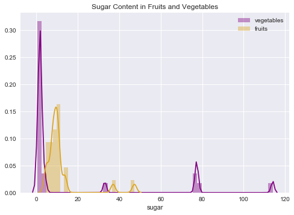

```python
# SUGAR CONTENT HISTOGRAM
x = fresh_vegetables["sugar"].dropna()
y = fresh_fruits["sugar"].dropna()

fig, ax = plt.subplots()

sns.distplot(x, ax=ax, color="purple", label="vegetables")
sns.distplot(y, ax=ax, color="goldenrod", label="fruits")
plt.legend()
ax.set_title("Sugar Content in Fruits and Vegetables")

sns.plt.show()
```

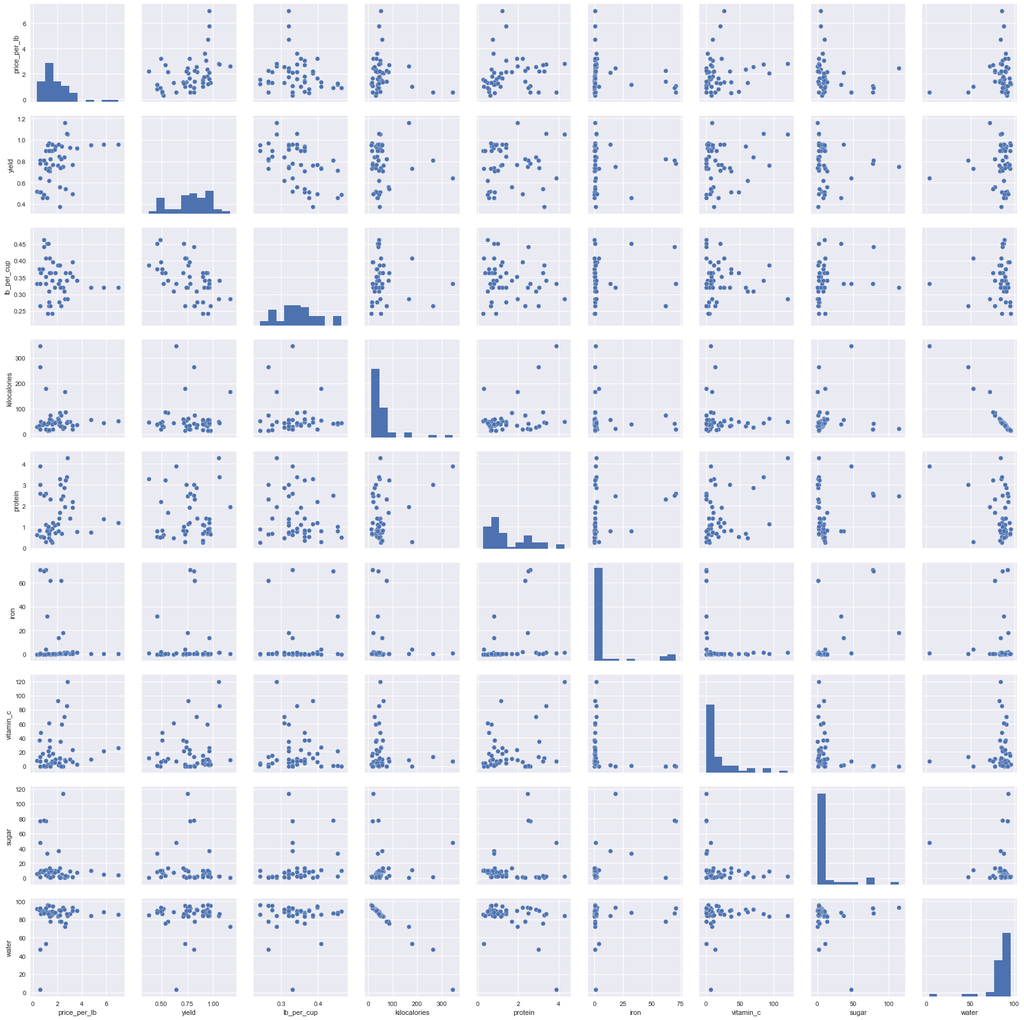

```python
# SCATTER PLOT MATRIX
sns.pairplot(fresh[["price_per_lb", "yield", "lb_per_cup", "kilocalories", "protein", "iron", "vitamin_c", "sugar", "water"]].dropna())

sns.plt.show()
```

## Standardizing All Columns

Despite the above plot showing otherwise, in order to create a model to rank foods on the "best" combination of price, yield, and nutrition, I am assuming that all of the numeric variables are normally distributed. I am defining the best combination of price, yield, and nutrition by a ranking system created by adding together the standard Z-scores of the variables of my interest. (I subtract the standard Z-scores of the variables for which I believe would make the combination "worse".)  
In the following cells, I am subsetting my columns of interest and the food name. </font>

```python
df_to_standardize = fresh[["food", "price_per_lb", "yield", "water", "kilocalories","protein", "sugar", "vitamin_c", "iron"]]
```

```python
df_to_standardize.head()
```

|  | food | price_per_lb | yield | water | kilocalories | protein | sugar | vitamin_c | iron |
| --- | --- | --- | --- | --- | --- | --- | --- | --- | --- |
| 0 | watermelon | 0.333412 | 0.52 | 91.45 | 30 | 0.61 | 6.20 | 8.1 | 0.24 |
| 1 | cantaloupe | 0.535874 | 0.51 | 90.15 | 34 | 0.84 | 7.86 | 36.7 | 0.21 |
| 2 | tangerines | 1.377962 | 0.74 | 85.17 | 53 | 0.81 | 10.58 | 26.7 | 0.15 |
| 3 | strawberries | 2.358808 | 0.94 | 90.95 | 32 | 0.67 | 4.89 | 58.8 | 0.41 |
| 4 | plums | 1.827416 | 0.94 | 87.23 | 46 | 0.70 | 9.92 | 9.5 | 0.17 |

The names of the measurements of variables are stored in variable_names. I use this to create a new column for the standard Z-score of each of the variables for each of the food items. </font>

```python
variable_names = list(df_to_standardize.iloc[:,-8:].columns)

for variable in variable_names:
    new_col_name = variable+"_stdz"
    df_to_standardize[new_col_name] = (df_to_standardize[variable] - df_to_standardize[variable].mean()) / df_to_standardize[variable].std(ddof=0)
```

```python
df_to_standardize.head()
```

|  | food | price_per_lb | yield | water | kilocalories | protein | sugar | vitamin_c | iron | price_per_lb_stdz | yield_stdz | water_stdz | kilocalories_stdz | protein_stdz | sugar_stdz | vitamin_c_stdz | iron_stdz |
| --- | --- | --- | --- | --- | --- | --- | --- | --- | --- | --- | --- | --- | --- | --- | --- | --- | --- |
| 0 | watermelon | 0.333412 | 0.52 | 91.45 | 30 | 0.61 | 6.20 | 8.1 | 0.24 | -1.259123 | -1.441425 | 0.492524 | -0.464559 | -0.874686 | -0.334932 | -0.430434 | -0.412948 |
| 1 | cantaloupe | 0.535874 | 0.51 | 90.15 | 34 | 0.84 | 7.86 | 36.7 | 0.21 | -1.101952 | -1.496440 | 0.404328 | -0.398145 | -0.654746 | -0.265161 | 0.645426 | -0.414413 |
| 2 | tangerines | 1.377962 | 0.74 | 85.17 | 53 | 0.81 | 10.58 | 26.7 | 0.15 | -0.448235 | -0.231116 | 0.066472 | -0.082679 | -0.683434 | -0.150838 | 0.269251 | -0.417343 |
| 3 | strawberries | 2.358808 | 0.94 | 90.95 | 32 | 0.67 | 4.89 | 58.8 | 0.41 | 0.313200 | 0.869166 | 0.458603 | -0.431352 | -0.817310 | -0.389992 | 1.476772 | -0.404646 |
| 4 | plums | 1.827416 | 0.94 | 87.23 | 46 | 0.70 | 9.92 | 9.5 | 0.17 | -0.099322 | 0.869166 | 0.206228 | -0.198903 | -0.788622 | -0.178578 | -0.377769 | -0.416366 |

Because I would like the additive total to be lower if the food item has a high price, too many calories, too much sugar, or too much water, I want these columns to result in a decrease in the rankings of food items. </font>

```python
# MAKING ADJUSTMENTS TO VALUES (FOR VALUES WE WANT TO BE LOW)
df_to_standardize["price_per_lb_stdz"] = -1*(df_to_standardize["price_per_lb_stdz"])
df_to_standardize["kilocalories_stdz"] = -1*(df_to_standardize["kilocalories_stdz"])
df_to_standardize["sugar_stdz"] = -1*(df_to_standardize["sugar_stdz"])
df_to_standardize["water_stdz"] = -1*(df_to_standardize["water_stdz"])
```

```python
df_to_standardize.head()
```

|  | food | price_per_lb | yield | water | kilocalories | protein | sugar | vitamin_c | iron | price_per_lb_stdz | yield_stdz | water_stdz | kilocalories_stdz | protein_stdz | sugar_stdz | vitamin_c_stdz | iron_stdz |
| --- | --- | --- | --- | --- | --- | --- | --- | --- | --- | --- | --- | --- | --- | --- | --- | --- | --- |
| 0 | watermelon | 0.333412 | 0.52 | 91.45 | 30 | 0.61 | 6.20 | 8.1 | 0.24 | 1.259123 | -1.441425 | -0.492524 | 0.464559 | -0.874686 | 0.334932 | -0.430434 | -0.412948 |
| 1 | cantaloupe | 0.535874 | 0.51 | 90.15 | 34 | 0.84 | 7.86 | 36.7 | 0.21 | 1.101952 | -1.496440 | -0.404328 | 0.398145 | -0.654746 | 0.265161 | 0.645426 | -0.414413 |
| 2 | tangerines | 1.377962 | 0.74 | 85.17 | 53 | 0.81 | 10.58 | 26.7 | 0.15 | 0.448235 | -0.231116 | -0.066472 | 0.082679 | -0.683434 | 0.150838 | 0.269251 | -0.417343 |
| 3 | strawberries | 2.358808 | 0.94 | 90.95 | 32 | 0.67 | 4.89 | 58.8 | 0.41 | -0.313200 | 0.869166 | -0.458603 | 0.431352 | -0.817310 | 0.389992 | 1.476772 | -0.404646 |
| 4 | plums | 1.827416 | 0.94 | 87.23 | 46 | 0.70 | 9.92 | 9.5 | 0.17 | 0.099322 | 0.869166 | -0.206228 | 0.198903 | -0.788622 | 0.178578 | -0.377769 | -0.416366 |

Now we have the Z-scores of our variables and have multiplied the values of variables that we want to be low, we will add up the standard Z-scores to create a final score for each of the food items. </font>

```python
# SUMMING UP THE STDZ COLUMNS
df_to_standardize["totals"] = df_to_standardize.iloc[:,-8:].sum(axis=1)
```

According to this ranking method, the following food items have the best combination of price, yield, and nutrition. </font>

```python
# THE TOP 10 FOODS BY THIS METRIC
df_to_standardize.sort_values(by="totals", ascending=False)[0:10]
```

[output not shown]

As expected, much of these food items are vegetables and not fruits due to fruits' high sugar content. It is also promising that Kale is the first food item on the list because Kale is very well-regarded amongst healthy eaters.  
We can also plot the distribution of scores for this model. </font>

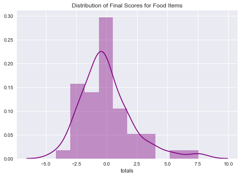

```python
# SCORE DISTRIBUTION HISTOGRAM
x = df_to_standardize["totals"]

sns.distplot(x, color="purple")
plt.title("Distribution of Final Scores for Food Items")

sns.plt.show()
```